# Python数据可视化

## 1. 基础

### 1.1 可视化工具？

- Origin（非跨平台）
- Matlab（跨平台）
- word / excel / ppt / visio
- Python相关库
  - [matplotlib](https://matplotlib.org/index.html)
  - [opencv](https://docs.opencv.org/3.0-beta/doc/py_tutorials/py_tutorials.html)
  - [seaborn](http://seaborn.pydata.org/index.html)
  - [ggplot](http://ggplot.yhathq.com/)
  - [bokeh](http://bokeh.pydata.org/en/latest/)
  - [pygal](http://www.pygal.org/en/latest/index.html)
  - [plotly](https://plot.ly/python/)

### 1.2 安装相关python库

- `python -m pip install numpy matplotlib opencv-python Image scipy imageio scikit-image`
- `python -m pip install jupyter`

### 1.3 如何使用？

- 忘记函数、参数名称，出现bug： **官方文档**、Google、Stackoverflow等
- **现用现查**
- 只是一种工具，不要本末倒置

## 2. 绘制图像

### 2.1 折线图 / '曲'线图

主要函数：

- `matplotlib.pyplot.plot`

```python
%matplotlib inline

import numpy as np
import matplotlib.pyplot as plt
```

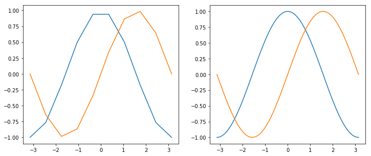

```python
# 定义图
plt.figure(figsize=[12, 5])

# 定义函数
X = np.linspace(-np.pi, np.pi, 10)
Y_cos, Y_sin = np.cos(X), np.sin(X)

# 绘制函数
plt.subplot(121)
plt.plot(X, Y_cos)
plt.plot(X, Y_sin)

plt.subplot(122)
X = np.linspace(-np.pi, np.pi, 100)
Y_cos, Y_sin = np.cos(X), np.sin(X)
plt.plot(X, Y_cos)
plt.plot(X, Y_sin)

# 展示
plt.show()
```

#### 如何美化

- 颜色
- 样式
- 标题
- 坐标轴
- 脊柱
- 图例
- 注释
- more...

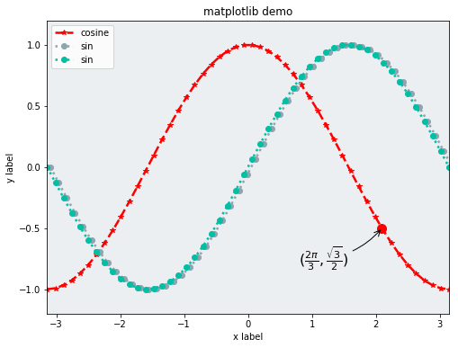

```python
# 定义图
plt.figure(figsize=[8, 6])

# 定义函数
X = np.linspace(-np.pi, np.pi, 50)
Y_cos, Y_sin = np.cos(X), np.sin(X)

# 绘制函数
plt.plot(X, Y_cos, color='red', marker='*', linewidth=2.5, linestyle='--', label='cosine')
plt.plot(X + 0.05, Y_sin, color='#90a4ae', marker='o', linewidth=2.5, linestyle=':', label='sin')
plt.plot(X, Y_sin, color='#00bfa5', marker='o', linewidth=2.5, linestyle=':', label='sin')

# 标题
plt.title("matplotlib demo")

# 坐标轴
plt.xlim(X.min(), X.max())
plt.ylim(-1.2, 1.2)

plt.xlabel('x label')
plt.ylabel('y label')


# 脊柱
# ax = plt.gca()
# ax.spines['right'].set_color('none')
# ax.spines['top'].set_color('none')
# ax.xaxis.set_ticks_position('bottom')
# ax.spines['bottom'].set_position(('data', 0))
# ax.yaxis.set_ticks_position('left')
# ax.spines['left'].set_position(('data', 0))

# 图例
plt.legend(loc='upper left')

# 注释
x = 2 * np.pi / 3
plt.scatter([x, ], [np.cos(x), ], 100, color='red')
plt.annotate(r'$ ( \frac{2\pi}{3}, \frac{\sqrt{3}}{2} )$',
            xy=(x, np.cos(x)),
            xycoords='data',
            xytext=(0.8, -0.8),
            fontsize=16,
            arrowprops=dict(arrowstyle='->', connectionstyle="arc3, rad=.2"))

# 背景颜色
ax = plt.gca()
ax.set_facecolor('#eceff1')

# 展示
plt.show()
```

### 2.2 子图

主要函数：

- `matplotlib.pyplot.subplot`
- `matplotlib.pyplot.gridspec`

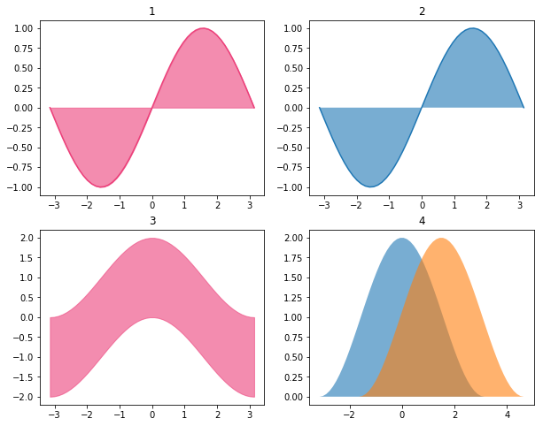

```python
plt.figure(figsize=[10, 8])

plt.subplot(221)  # 2行2列的第一个子图
plt.plot(X, Y_sin, color='#ec407a')
plt.title('1')
plt.fill_between(X, 0, Y_sin, color='#ec407a', alpha=0.6)

plt.subplot(222)
plt.plot(X, Y_sin)
plt.fill_between(X, 0, Y_sin, alpha=0.6)
plt.title('2')

plt.subplot(223)
plt.fill_between(X, Y_cos - 1, Y_cos + 1, color='#ec407a', alpha=0.6)
plt.title('3')

plt.subplot(224)
plt.title('4')
plt.fill_between(X, 0, Y_cos + 1, alpha=0.6)
plt.fill_between(X + 1.5, 0, Y_cos + 1, alpha=0.6)
```

```
([], <a list of 0 Text yticklabel objects>)
```

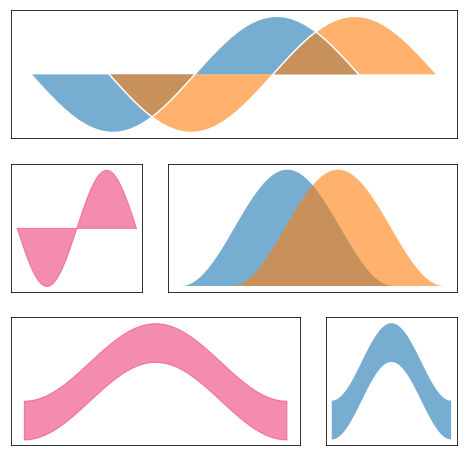

```python
import matplotlib.gridspec as gridspec

plt.figure(figsize=[8, 8])
grid = gridspec.GridSpec(3, 3)

plt.subplot(grid[0, :])
plt.xticks([])
plt.yticks([])
plt.plot(X, Y_sin, color='w')
plt.fill_between(X[50:], 0, Y_sin[50:], color='#ec407a', alpha=0.6)
plt.fill_between(X[:50], 0, Y_sin[:50], alpha=0.6)
X += 1.5
plt.plot(X, Y_sin, color='w')
plt.fill_between(X[50:], 0, Y_sin[50:], color='#ec407a', alpha=0.6)
plt.fill_between(X[:50], 0, Y_sin[:50], alpha=0.6)

plt.subplot(grid[1, 0])
plt.xticks([])
plt.yticks([])
plt.fill_between(X, 0, Y_sin, color='#ec407a', alpha=0.6)

plt.subplot(grid[1, 1:])
plt.xticks([])
plt.yticks([])
plt.fill_between(X, 0, Y_cos + 1, alpha=0.6)
plt.fill_between(X + 1.5, 0, Y_cos + 1, alpha=0.6)

plt.subplot(grid[2, :2])
plt.xticks([])
plt.yticks([])
plt.fill_between(X, Y_cos, Y_cos + 1, color='#ec407a', alpha=0.6)

plt.subplot(grid[2, 2])
plt.fill_between(X, Y_cos, Y_cos + 1, alpha=0.6)
plt.xticks([])
plt.yticks([])
```

## 2.3 散点图

主要函数：

- `matplotlib.pyplot.scatter`

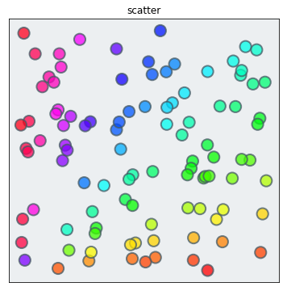

```python
plt.figure(figsize=[6, 6])

#  定义数据
X = np.random.randint(0, 1000, [100,])
Y = np.random.randint(0, 1000, [100,])
c = np.arctan2(Y, X)

#  散点图
plt.scatter(X, Y, alpha=0.75, c=c, cmap='hsv', edgecolor='#455a64', s=200, linewidths=2)
plt.xticks([])
plt.yticks([])
plt.title('scatter')

# 背景颜色
ax = plt.gca()
ax.set_facecolor('#eceff1')
```

## 2.4 条形图

主要函数：

- `matplotlib.pyplot.bar`

```
([], <a list of 0 Text yticklabel objects>)
```

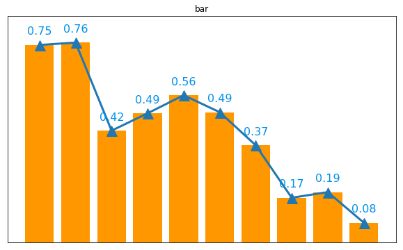

```python
# 生成数据
N = 10
X = np.arange(N)
Y = (1. - X / float(N)) * np.random.uniform(0.5, 1.0, N)

# 条形图
plt.figure(figsize=[10, 6])
plt.bar(X, Y, facecolor='#ff9800')
plt.plot(X, Y, marker='^', markersize=15, linewidth=3)
plt.title('bar')

# 显示数据
for x, y in zip(X, Y):
    plt.text(x, y + 0.03,
             '%.2f' % y, ha='center', va='bottom',
             fontdict={'color': '#0091ea',
                      'size': 16})

plt.ylim(0., Y.max() + 0.1)
plt.xticks([])
plt.yticks([])
```

## 2.5 饼状图

主要函数：

- `matplotlib.pyplot.pie`

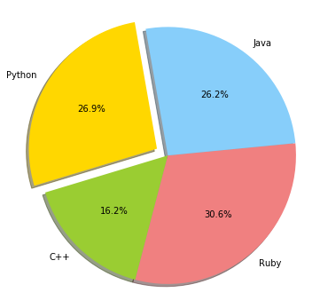

```python
# 定义数据

labels = 'Python', 'C++', 'Ruby', 'Java'
sizes = [215, 130, 245, 210]
colors = ['gold', 'yellowgreen', 'lightcoral', 'lightskyblue']
explode = (0.1, 0, 0, 0)

# 饼状图
plt.figure(figsize=[6, 6])
plt.pie(sizes,
        explode=explode, labels=labels, colors=colors,
        autopct='%1.1f%%', shadow=True, startangle=100)

plt.axis('equal')
plt.show()
```

## 2.5 3D图

主要函数：

- `mpl_toolkits.mplot3d.Axes3D`

```python
from mpl_toolkits.mplot3d import Axes3D
```

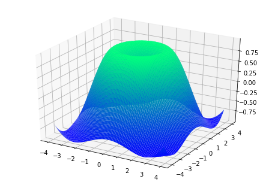

```python
# 定义数据
X = np.arange(-4, 4, 0.1)
Y = np.arange(-4, 4, 0.1)
X, Y = np.meshgrid(X, Y)
R = np.sqrt(X ** 2 + Y ** 2)
Z1 = np.sin(R)

# 绘图
fig = plt.figure()
ax = Axes3D(fig)
ax.plot_surface(X, Y, Z1, rstride=1, cstride=1, cmap='winter')
```

## 3. 图像可视化

RGB图像存储格式一般为多维数组：`H x W x 3`

### 3.1 读取图片（RGB图片为例）、显示图片

| 函数 | 备注 |
| --- | --- |
| `PIL.Image.open` | HxWx3 (RGB) (二进制编码方式读取，需要`np.array()`转化） |
| `cv2.imread` | HxWx3 **(BGR)**, 速度最快 |
| `matplotlib.image.imread` | HxWx3 (RGB) |
| `scipy.misc.imread (imageio.imread)` | HxWx3 (RGB) |
| `skimage.io.imread` | HxWx3 (RGB) |

```
(224L, 200L, 3L)
(224L, 200L, 3L)
(224L, 200L, 3L)
(224L, 200L, 3L)
(224L, 200L, 3L)
(224L, 200L, 3L)
```

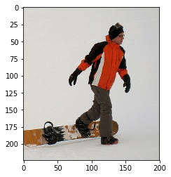

```python
from PIL import Image
import cv2
import matplotlib.image as pltimg
import scipy.misc as scimisc
import imageio
import skimage.io as skiio


# PIL
img = Image.open('data/1.jpg')
img = np.array(img)
print(img.shape)

# opencv
img = cv2.imread('data/1.jpg')[:, :, ::-1]  # 需要将BGR转化为RGB
print(img.shape)

# matplotlib
img = pltimg.imread('data/1.jpg')
print(img.shape)

# scipy
img = scimisc.imread('data/1.jpg')
print(img.shape)

# imageio
img = imageio.imread('data/1.jpg')
print(img.shape)

# skimage
img = skiio.imread('data/1.jpg')
print(img.shape)

# 显示图片
plt.imshow(img)
```

### 3.2 检测框

`boundingbox`框一般出现在object detection等任务中。

```python
box = np.load('data/box.npy')
print("box:", box)
```

```
('box:', array([[ 60,  20],
       [160, 201]], dtype=int64))
```

`box` 为框的坐标：`[[x1, y1], [x2, y2]]`

```
('image shape:', (224L, 200L, 3L))
```

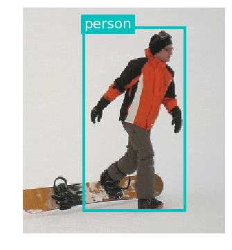

```python
#　＝＝＝＝添加box框＝＝＝＝
import matplotlib.patches as pth

# 显示原图
plt.figure(figsize=[6, 6])
plt.imshow(img, alpha=0.9)
plt.axis('off')

# 显示box框
ax = plt.gca()
rec = pth.Rectangle(box[0],
                    box[1][0] - box[0][0],
                    box[1][1] - box[0][1],
                    facecolor='none', edgecolor='c', linewidth=4)
ax.add_patch(rec)

# 添加文字框
plt.text(box[0, 0],
         box[0, 1],
         "person",
         size=20,
         fontdict=dict(color='w'),
         bbox=dict(edgecolor='c',
                   facecolor='c')
        )

print("image shape:", img.shape)
```

### 3.3 Mask蒙版

mask一般出现在semantic segmentation、instance segmentation等任务中，mask上不同值代表原图中不同的物体。

```python
mask = np.load('data/mask.npy')
print('shape:', mask.shape)
print('max:', mask.max())
print('min:', mask.min())
```

```
('shape:', (224L, 200L))
('max:', 1)
('min:', 0)
```

`mask`是二值化蒙版图片，值为`1`的区域为人所在区域，`0`的区域为背景，大小`224x200`与原图一样

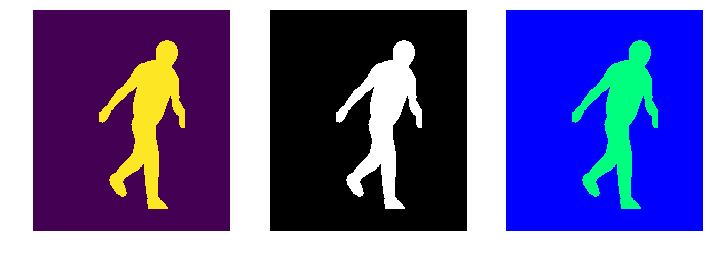

```python
# 显示mask
plt.figure(figsize=[12, 6])

# default colormap
plt.subplot(131)
plt.imshow(mask)  # 显示为伪彩色
plt.axis('off')

# `gray` colormap
plt.subplot(132)
plt.imshow(mask, cmap='gray')
plt.axis('off')

plt.subplot(133)
plt.axis('off')
plt.imshow(mask, cmap='winter')
```

利用`alpha`参数,将mask蒙版叠加在原图上

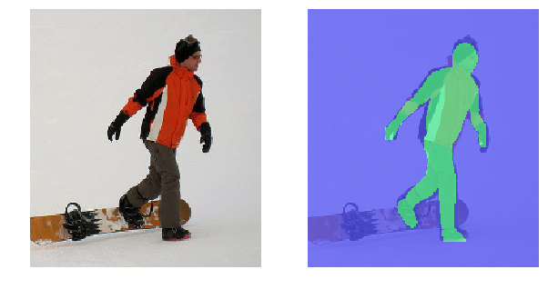

```python
plt.figure(figsize=[10, 8])

plt.subplot(121)
plt.imshow(img)
plt.axis('off')

plt.subplot(122)
# 原图
plt.imshow(img, alpha=0.5)
plt.axis('off')
# mask
plt.imshow(mask, cmap='winter', alpha=0.5)
```

将原图和mask图片融合为一张图片再显示

- mask为一通道图片，首先用`cv2.applyColorMap`转化为三通道RGB图片
- 通过手动设定`alpha`参数，将两图片融合

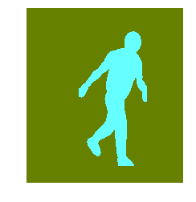

```python
color_mask = cv2.applyColorMap((mask * 255.).astype(np.uint8), cv2.COLORMAP_SUMMER)
plt.axis('off')
plt.imshow(color_mask)
```

```python
# 融合图片
alpha = 0.65
mask_idx = (mask == 1)
img_mask = img.copy()
img_mask[mask_idx] = img_mask[mask_idx] * (1. - alpha) + color_mask[mask_idx] * alpha
```

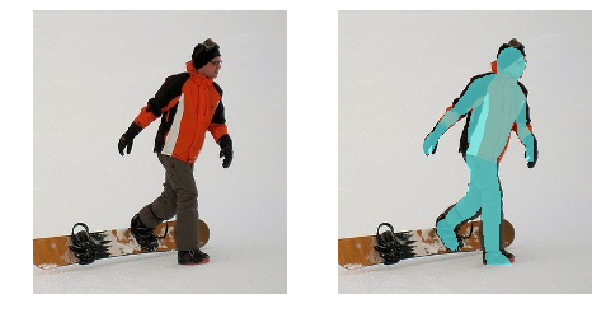

```python
plt.figure(figsize=[10, 8])

plt.subplot(121)
plt.axis('off')
plt.imshow(img)

plt.subplot(122)
plt.axis('off')
plt.imshow(img_mask)
```

### 3.4 关节点

人的关节点keypoint一般出现在human pose estimation等任务重，存在形式一般为每个关节点的坐标。

```python
kps = np.load('data/kps.npy')
print('kps:', kps)
print('shape:', kps.shape)
```

```
('kps:', array([[120, 189],
       [121, 148],
       [101, 113],
       [124, 114],
       [109, 150],
       [ 86, 168],
       [ 75,  99],
       [ 92,  80],
       [114,  58],
       [145,  65],
       [145,  91],
       [152, 106],
       [132,  57],
       [144,  36]], dtype=int64))
('shape:', (14L, 2L))
```

```python
np.save('kps.npy', np.array([
    [120, 189],
    [121, 148],
    [101, 113],
    [124, 114],
    [109, 150],
    [86, 168],
    [75, 99],
    [92, 80],
    [114, 58],
    [145, 65],
    [145, 91],
    [152, 106],
    [132, 57],
    [144, 36]
]))
```

`kps`为`14x2`的`ndarray`格式，共14个关节点，每个关节点有2个量，`[x, y]`。

14个关节点名称顺序为：

```
0 - Right ankle
1 - Right knee
2 - Right hip
3 - Left hip
4 - Left knee
5 - Left ankle
6 - Right wrist
7 - Right elbow
8 - Right shoulder
9 - Left shoulder
10 - Left elbow
11 - Left wrist
12 - Neck
13 - Head top
```

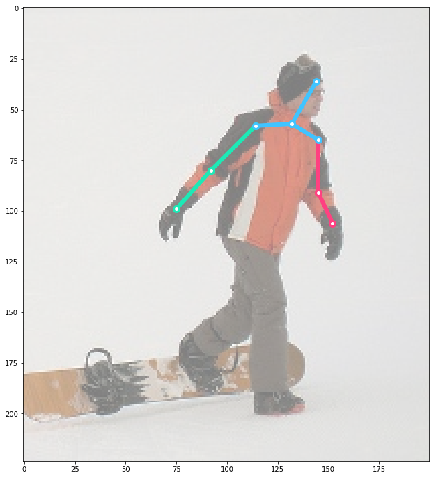

```python
plt.figure(figsize=[12, 12])

plt.imshow(img, alpha=0.5)

# 显示关节点
# 右上肢
plt.plot(kps[6:8, 0], kps[6:8, 1], c='#1de9b6',
         linewidth=6, markersize=8, marker='o', markeredgewidth=3, markerfacecolor='w')
plt.plot(kps[7:9, 0], kps[7:9, 1], c='#1de9b6',
         linewidth=6, markersize=8, marker='o', markeredgewidth=3, markerfacecolor='w')

# 左上肢
plt.plot(kps[9:11, 0], kps[9:11, 1], c='#ff4081',
         linewidth=6, markersize=8, marker='o', markeredgewidth=3, markerfacecolor='w')
plt.plot(kps[10:12, 0], kps[10:12, 1], c='#ff4081',
         linewidth=6, markersize=8, marker='o', markeredgewidth=3, markerfacecolor='w')

# 头
plt.plot(kps[12:14, 0], kps[12:14, 1], c='#40c4ff',
         linewidth=6, markersize=8, marker='o', markeredgewidth=3, markerfacecolor='w')
plt.plot([kps[8, 0], kps[12, 0]], [kps[8, 1], kps[12, 1]], c='#40c4ff',
         linewidth=6, markersize=8, marker='o', markeredgewidth=3, markerfacecolor='w')
plt.plot([kps[9, 0], kps[12, 0]], [kps[9, 1], kps[12, 1]], c='#40c4ff',
         linewidth=6, markersize=8, marker='o', markeredgewidth=3, markerfacecolor='w')
```